# Exercise4

Author

Sarah Lötscher

```r
#Load Packages
library(limma)
library(ggplot2)
library(reshape)
```

```r
#Parameters for simulation
nGenes <- 10000                   # number of "features"
nSamples <- 6                     # number of samples (split equal in 2 groups)
pDiff <- .1                       # percent of genes "differential
grp <- rep(0:1,each=nSamples/2)   # dummy variable for exp. group
trueFC <- 2                       # log-fold-change of truly DE

d0 <- 1
s0 <- 0.8
sd <- s0*sqrt(d0/rchisq(nGenes,df=d0))  # dist'n of s.d.
```

```r
#Create Table
y <- matrix(rnorm(nGenes*nSamples,sd=sd),nr=nGenes,nc=nSamples)

#Add in “differential expression”
indD <- 1:floor(pDiff*nGenes)
diff <- sample(c(-1,1),max(indD),replace=TRUE)*trueFC
y[indD,grp==1] <- y[indD,grp==1] + diff
```

## Question 1

First, do an exploratory analysis of the true and observed variances. For the observed variances, compute the residual variance for each row of y (i.e., pooled variance of the two simulated samples, not the row-wise variance; see the denominator of the classical two-sample t-statistic) and look at the distribution of them, of the true variances (from the simulated sd) and a scatter plot of true versus observed. Sometimes viewing variances on the log scale is preferred.

```r
#compute the residual variance

var0 = apply(y[,grp==0], 1, var)
var1 = apply(y[,grp==1], 1, var)

res_var=(var0+var1)/2

#Compute true variance
true_var=sd^2


#Data frame with variances
variance <- data.frame(true_var, res_var)
m_variance=melt(variance) #for plotting
```

```
Using  as id variables
```

```r
head(variance)
```

```
     true_var      res_var
1   19.858892 3.349817e+01
2    1.777802 7.757492e-01
3 3448.885350 3.876977e+03
4    1.848317 7.126579e+00
5    0.311709 6.967406e-02
6    1.298193 2.580042e+00
```

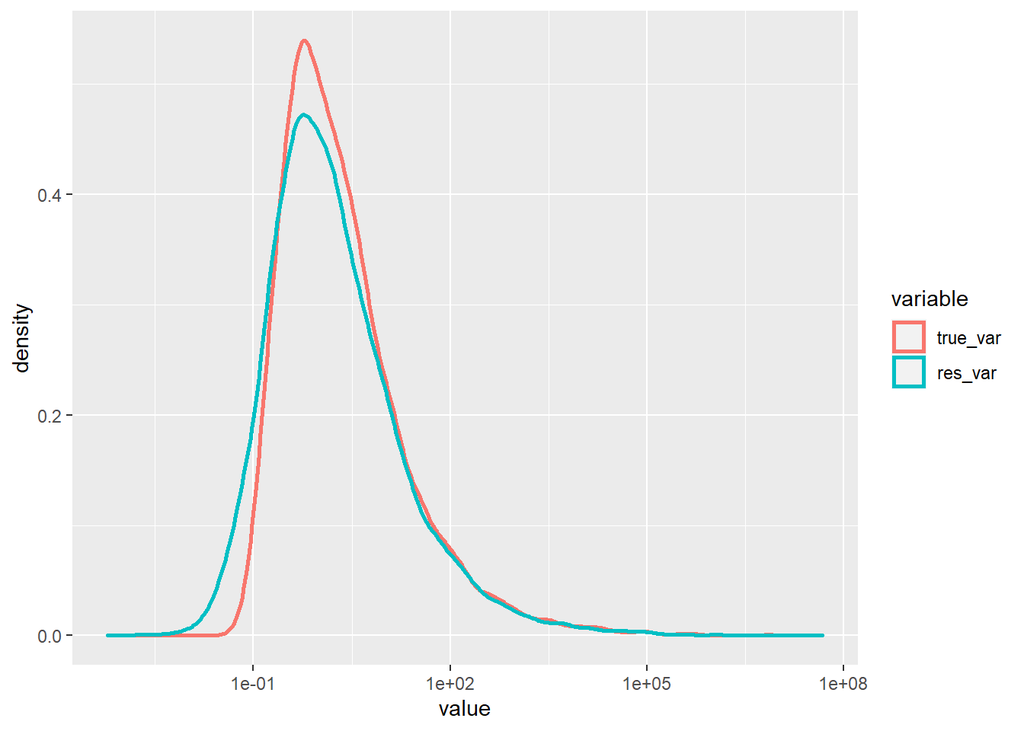

```r
#Look at distribution of variances as density plot
ggplot(m_variance, aes(x=value, color=variable)) + geom_density(size=1)+scale_x_continuous(trans = 'log10')
```

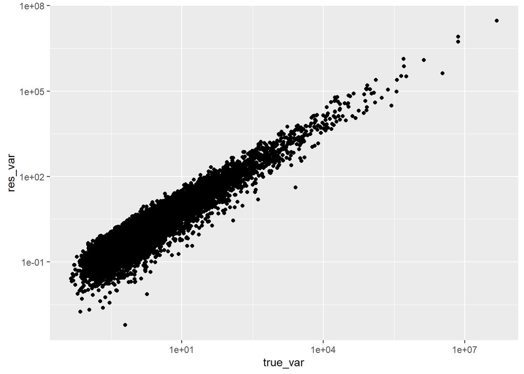

```r
#Scatter plot of true versus observed

ggplot(variance, aes(x = true_var, y = res_var))+geom_point() + scale_y_continuous(trans = 'log10')+scale_x_continuous(trans = 'log10')
```

## Question 2

Produce an additional visualization to show that you understand the differential expression that we introduced into the simulation.

```r
grp0av <- apply(y[, grp==0], 1, mean)
grp1av <- apply(y[, grp==1], 1, mean)
m_y <- data.frame(grp0av, grp1av)

m_y=melt(m_y)
```

```
Using  as id variables
```

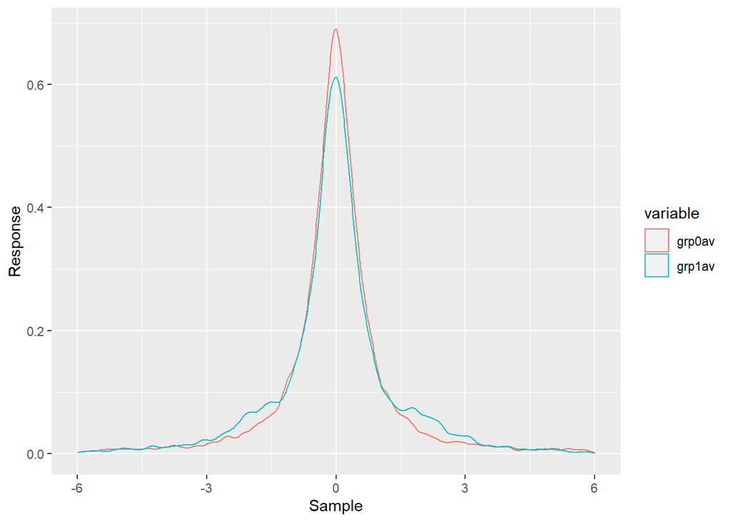

```r
ggplot(m_y, aes(x=value, colour=variable)) + geom_density() + xlim(-6,6) + xlab("Sample") + ylab("Response")
```

```r
(design <- model.matrix(~grp))
```

```
  (Intercept) grp
1           1   0
2           1   0
3           1   0
4           1   1
5           1   1
6           1   1
attr(,"assign")
[1] 0 1
```

## Question 3

In terms of the model that is fit for each feature, what is the interpretation of the two columns of this design matrix?

```r
(design <- model.matrix(~grp))
```

```
  (Intercept) grp
1           1   0
2           1   0
3           1   0
4           1   1
5           1   1
6           1   1
attr(,"assign")
[1] 0 1
```

The two columns describe the model parameters. The intercept column shows the intercepts. The grp column descripes the expression change between the two groups.

```r
fit <- lmFit(y,design)
fit <- eBayes(fit)

names(fit)
```

```
 [1] "coefficients"     "rank"             "assign"           "qr"
 [5] "df.residual"      "sigma"            "cov.coefficients" "stdev.unscaled"
 [9] "pivot"            "Amean"            "method"           "design"
[13] "df.prior"         "s2.prior"         "var.prior"        "proportion"
[17] "s2.post"          "t"                "df.total"         "p.value"
[21] "lods"             "F"                "F.p.value"
```

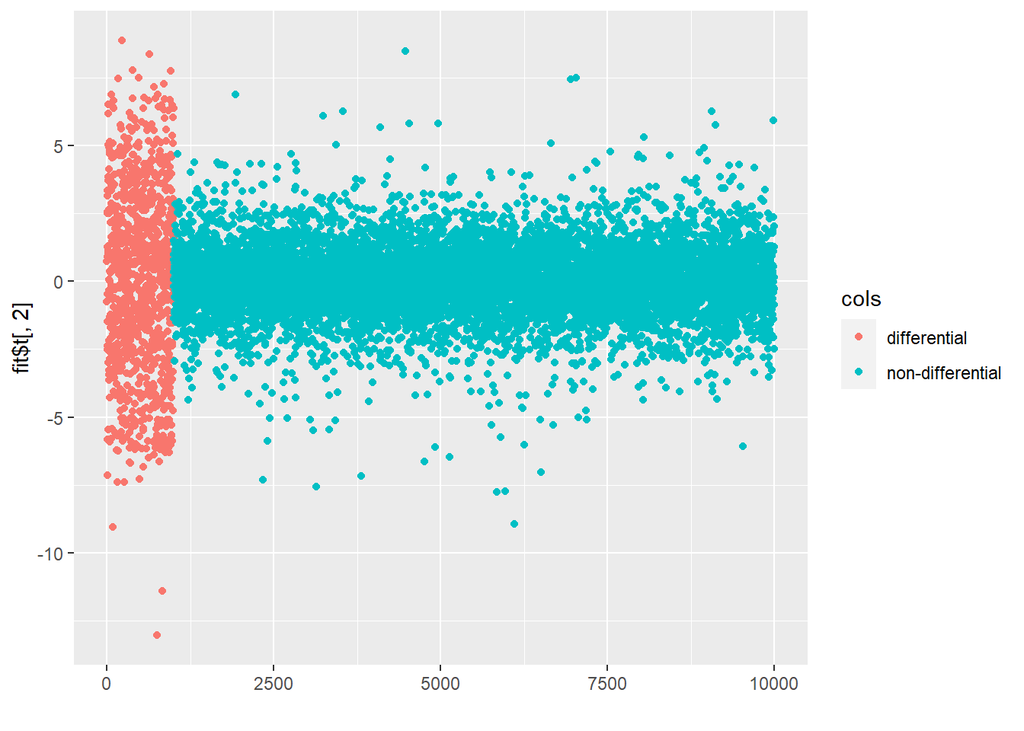

```r
cols <- rep("non-differential",nrow(y))
cols[indD] <- "differential"

qplot(y=fit$t[,2]) + geom_point(aes(colour=cols))
```

## Question 4

For each row of y, calculate also the classical 2-sample t-test. See ?t.test for more details about the built-in R function to do this calculation and convince yourself which arguments to use to match the classical t-test described in the lecture. Add a visualization similar to the above plot for the classical t-statistic and the log-fold-change (mean difference of the 2 groups). Which statistic best separates the truly differential from non-differential?

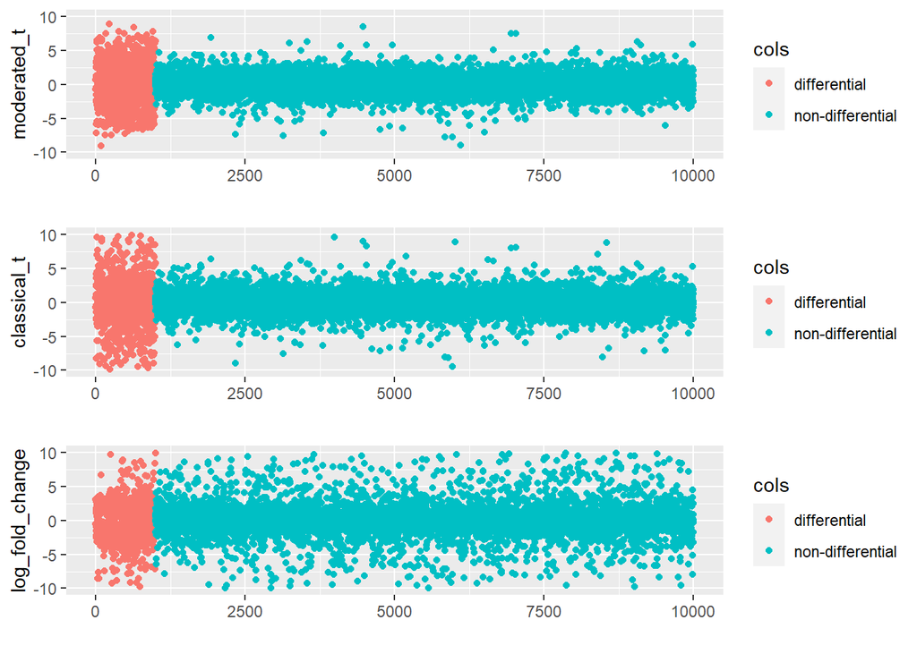

```r
#Calculate the statistics
moderated_t=fit$t[,2]
classical_t=fit$coef[,2]/fit$sigma/fit$stdev.unscaled[,2]
log_fold_change=fit$coef[,2]

#Get the plots
p1=qplot(y=moderated_t) + geom_point(aes(colour=cols)) + ylim(-10,10)
p2=qplot(y=classical_t) + geom_point(aes(colour=cols)) + ylim(-10,10)
p3=qplot(y=log_fold_change) + geom_point(aes(colour=cols)) + ylim(-10,10)

#Put three plots next to each other for comparison
gridExtra::grid.arrange(p1, p2, p3 )
```

The moderated t-statistic seems to give the best separation between the differential and non-differential samples.

## Question 5

Pick a reasonable metric to compare the methods, such as an ROC curve, false discovery plot, power versus achieved FDR. Using this metric/curve, formally compare the performance of the classical t-test, the moderated t-test and the log-fold-change or mean difference (fit$coef). Two packages that are useful for these kind of plots include: ROCR or iCOBRA.

```r
library(ROCR)

#Make the predictions
pred_moderated_t <- prediction(abs(moderated_t), !(cols=="non-differential"))
pred_classical_t <- prediction(abs(classical_t), !(cols=="non-differential"))
pred_log_fold_change <- prediction(abs(log_fold_change), !(cols=="non-differential"))

#Get the performances of the statistics
perf_moderated_t <- performance(pred_moderated_t, "tpr", "fpr")
perf_classical_t <- performance(pred_classical_t, "tpr", "fpr")
perf_log_fold_change <- performance(pred_log_fold_change, "tpr", "fpr")
```

ROC plot

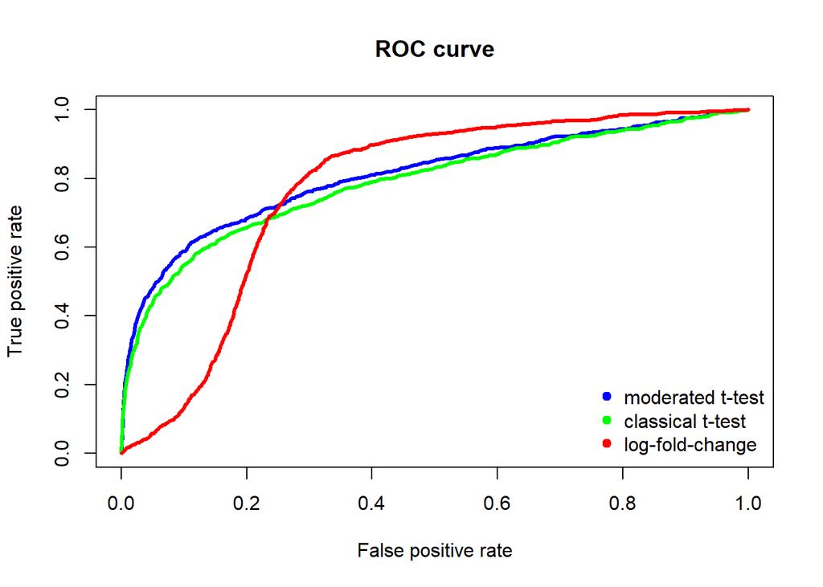

```r
plot(perf_moderated_t,lwd= 3,main= "ROC curve",col="blue")
plot(perf_classical_t,lwd= 3,add = TRUE,col="green")
plot(perf_log_fold_change,lwd= 3,add = TRUE,col="red")
legend("bottomright",legend = c("moderated t-test", "classical t-test", "log-fold-change"), col = c("blue", "green", "red"), pch = 19, bty = "n")
```

Precision/Recall plot

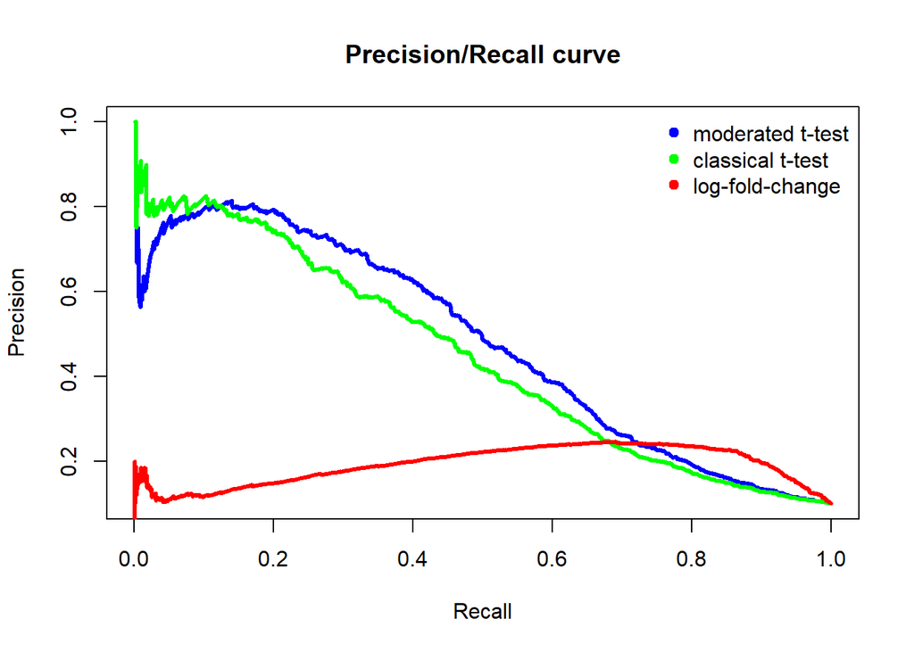

```r
#Get the performances of the statistics
perf_moderated_t <- performance(pred_moderated_t, "prec", "rec")
perf_classical_t <- performance(pred_classical_t, "prec", "rec")
perf_log_fold_change <- performance(pred_log_fold_change, "prec", "rec")

#Plot
plot(perf_moderated_t,lwd= 3,main= "Precision/Recall curve",col="blue")
plot(perf_classical_t,lwd= 3,add = TRUE,col="green")
plot(perf_log_fold_change,lwd= 3,add = TRUE,col="red")
legend("topright",legend = c("moderated t-test", "classical t-test", "log-fold-change"), col = c("blue", "green", "red"), pch = 19, bty = "n")
```

Comparing the performance plots the moderated t-test best separates the truly differential from non-differential.

```r
library("affy")
library("preprocessCore")
unzip("affy_estrogen.zip")
ddir <- "affy_estrogen"
dir(ddir)
```

```
[1] "high10-1.cel" "high10-2.cel" "high48-1.cel" "high48-2.cel" "low10-1.cel"
[6] "low10-2.cel"  "low48-1.cel"  "low48-2.cel"  "targets.txt"
```

```r
# preprocess affymetrix data
targets <- readTargets("targets.txt", path=ddir)
targets$time.h <- factor(targets$time.h)
targets
```

```
      filename estrogen time.h
1  low10-1.cel   absent     10
2  low10-2.cel   absent     10
3 high10-1.cel  present     10
4 high10-2.cel  present     10
5  low48-1.cel   absent     48
6  low48-2.cel   absent     48
7 high48-1.cel  present     48
8 high48-2.cel  present     48
```

```r
abatch <- ReadAffy(filenames=targets$filename,
                   celfile.path=ddir)
eset <- rma(abatch)  # bg correct, normalize, summarize
```

```
Background correcting
Normalizing
Calculating Expression
```

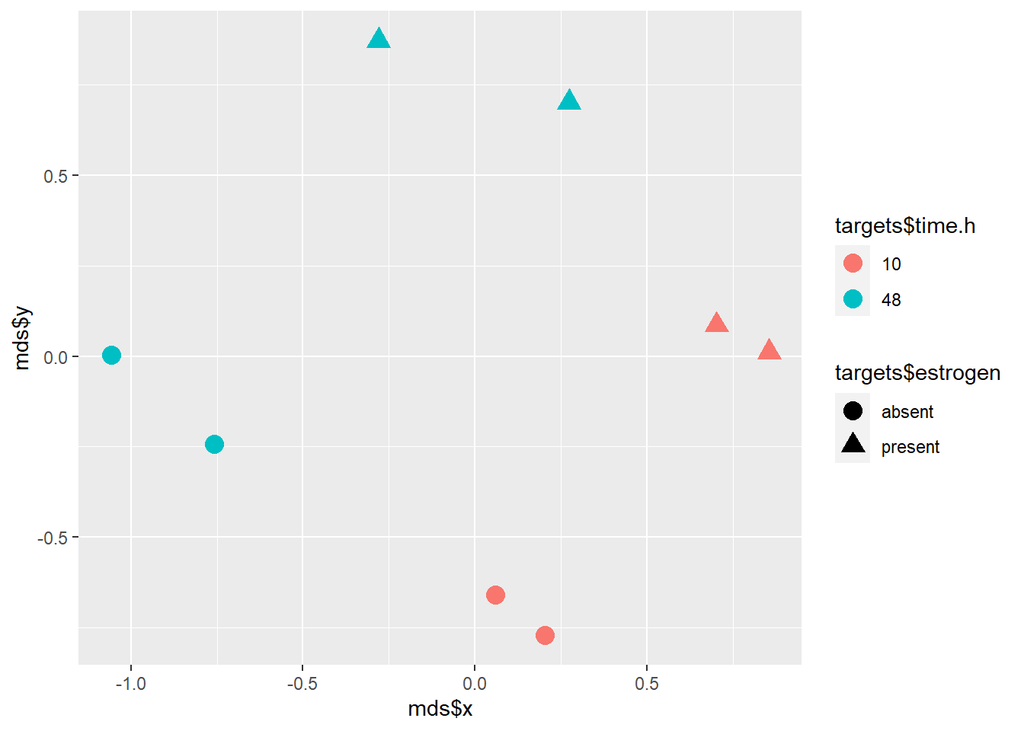

```r
mds <- plotMDS( exprs(eset), plot = FALSE)  # MDS plot
qplot(x=mds$x, mds$y) +
  geom_point(aes(shape=targets$estrogen,
                 colour=targets$time.h), size=4)
```

```r
# do the limma modeling
f <- paste(targets$estrogen,targets$time.h,sep="")
f <- factor(f)

# create design matrix
design <- model.matrix(~0+f)
colnames(design) <- levels(f)
design
```

```
  absent10 absent48 present10 present48
1        1        0         0         0
2        1        0         0         0
3        0        0         1         0
4        0        0         1         0
5        0        1         0         0
6        0        1         0         0
7        0        0         0         1
8        0        0         0         1
attr(,"assign")
[1] 1 1 1 1
attr(,"contrasts")
attr(,"contrasts")$f
[1] "contr.treatment"
```

```r
fit <- lmFit(eset, design)
```

```r
cont.matrix <- makeContrasts(E10="present10-absent10",
                             E48="present48-absent48",
                             Time="absent48-absent10",levels=design)
cont.matrix
```

```
           Contrasts
Levels      E10 E48 Time
  absent10   -1   0   -1
  absent48    0  -1    1
  present10   1   0    0
  present48   0   1    0
```

```r
fit2  <- contrasts.fit(fit, cont.matrix)
fit2  <- eBayes(fit2)
class(fit2)
```

```
[1] "MArrayLM"
attr(,"package")
[1] "limma"
```

```r
names(fit2)
```

```
 [1] "coefficients"     "rank"             "assign"           "qr"
 [5] "df.residual"      "sigma"            "cov.coefficients" "stdev.unscaled"
 [9] "pivot"            "Amean"            "method"           "design"
[13] "contrasts"        "df.prior"         "s2.prior"         "var.prior"
[17] "proportion"       "s2.post"          "t"                "df.total"
[21] "p.value"          "lods"             "F"                "F.p.value"
```

```r
topTable(fit2, coef=1, n=5)
```

```
            logFC   AveExpr        t      P.Value    adj.P.Val        B
39642_at 2.939428  7.876515 23.71715 4.741579e-09 3.128295e-05 9.966810
910_at   3.113733  9.660238 23.59225 4.955715e-09 3.128295e-05 9.942522
31798_at 2.800195 12.115778 16.38509 1.025747e-07 3.511070e-04 7.977290
41400_at 2.381040 10.041553 16.22463 1.112418e-07 3.511070e-04 7.916921
40117_at 2.555282  9.676557 15.68070 1.472942e-07 3.576234e-04 7.705093
```

```r
topTable(fit2, coef=2, n=5)
```

```
            logFC   AveExpr        t      P.Value    adj.P.Val         B
910_at   3.855061  9.660238 29.20918 8.266125e-10 1.043598e-05 11.606193
31798_at 3.597334 12.115778 21.04947 1.284430e-08 7.631722e-05  9.890557
1854_at  3.340896  8.532099 20.19564 1.813478e-08 7.631722e-05  9.641399
38116_at 3.758891  9.513109 16.85669 8.116230e-08 2.511100e-04  8.480197
38065_at 2.993641  9.097183 16.20914 1.121213e-07 2.511100e-04  8.214175
```

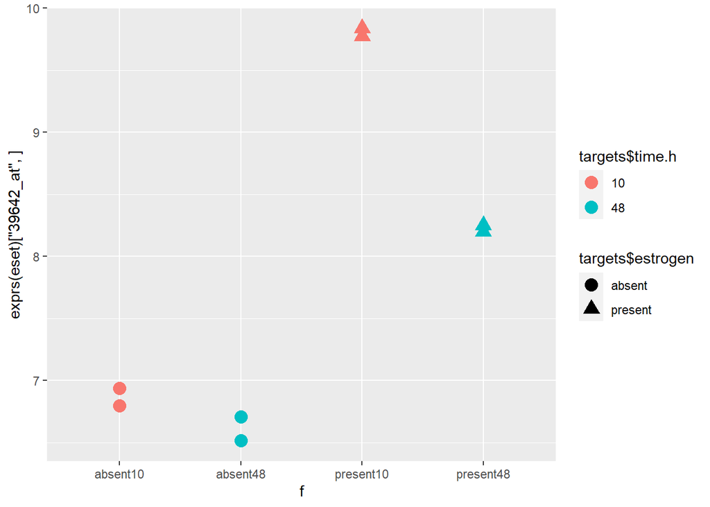

```r
qplot(x=f, y=exprs(eset)["39642_at",],) +
  geom_point(aes(shape=targets$estrogen,
                 colour=targets$time.h), size=4)
```

## Question 6

From the matrix of summarized Affymetrix data that went into the limma pipeline in the first place (exprs(eset)), manually calculate the logFC and AveExpr for one of the top differentially expressed features.

```r
#Get the top differentially expressed feature --> try to manually calculate these values
topTable(fit2,coef=2)[1,]
```

```
          logFC  AveExpr        t      P.Value    adj.P.Val        B
910_at 3.855061 9.660238 29.20918 8.266125e-10 1.043598e-05 11.60619
```

```r
#Calculate AveExpr
topfeauturename<-rownames(topTable(fit2,coef=2)[1,])
AE<-exprs(eset)[topfeauturename,]
mean(AE)
```

```
[1] 9.660238
```

```r
#Calculate logFC
mean(AE[f=="present48"])-mean(AE[f=="absent48"])
```

```
[1] 3.855061
```